# midterm1

Huiyi Huang

12/23/2019

```r
library(gganimate)
library(readxl)
library(dplyr)
library(tidyverse)
```

```r
library(ggplot2)
library(gifski)
library(haven)

hdd0318cy <- read_sas("hdd0318cy.sas7bdat",
    NULL)
```

```r
y=hdd0318cy %>%
  select(sex,age,admtype,preopday,los,service,payer,race,yod,tot,yoa,moa)
```

Data cleaning

```r
y=y %>%
  filter_all(~!is.na(.)) %>%
  filter_all(~!(.=='')) %>%
  filter(sex!="9")
```

```r
y1=y %>%
  group_by(yoa) %>%
  summarise(mean_age=mean(age)) %>%
  mutate(mean_age=round(mean_age,0))
```

PLOT 1

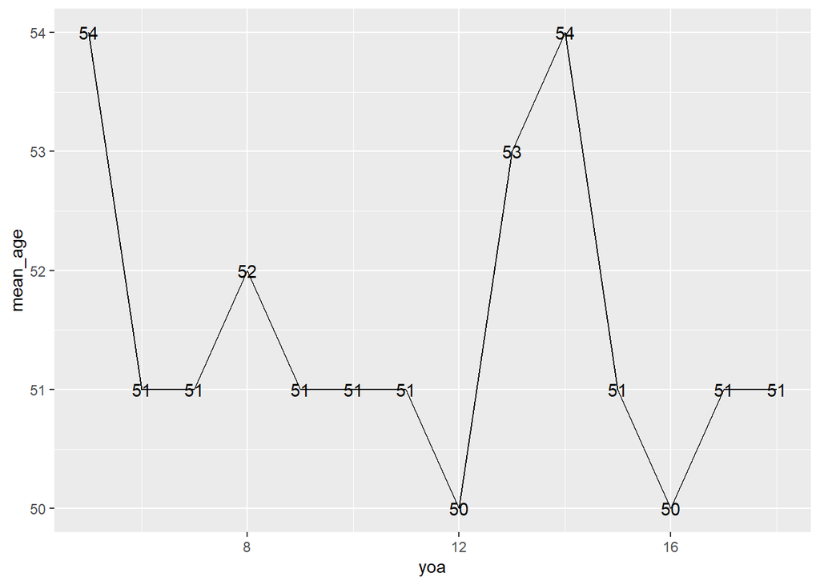

```r
ggplot(y1,aes(yoa,mean_age))+
  geom_line()+
  geom_text(aes(label=mean_age))
```

PLOT 2

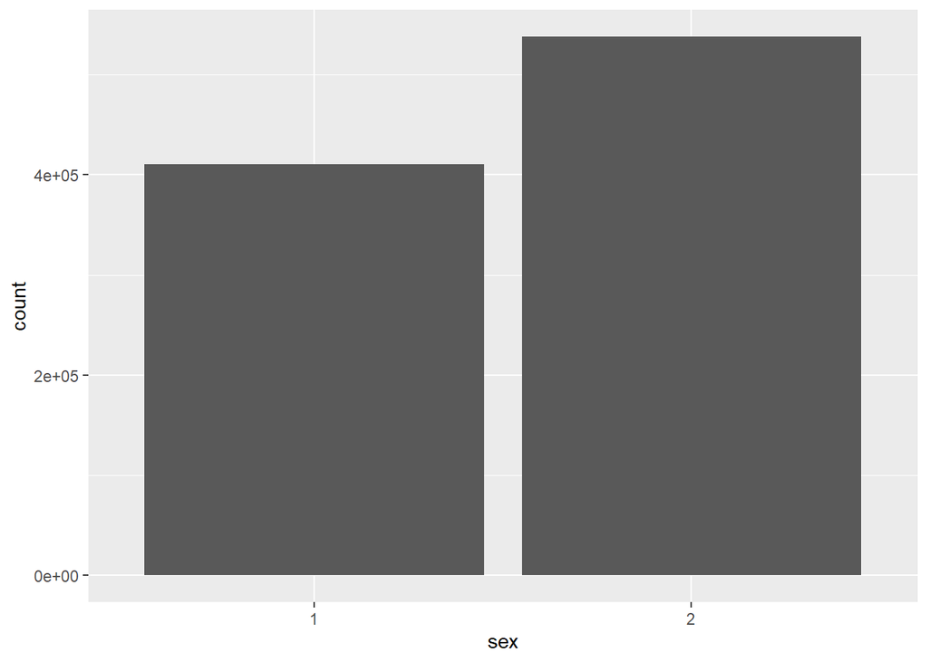

```r
ggplot(y,aes(sex))+
  geom_bar(position='dodge')
```

PLOT 3

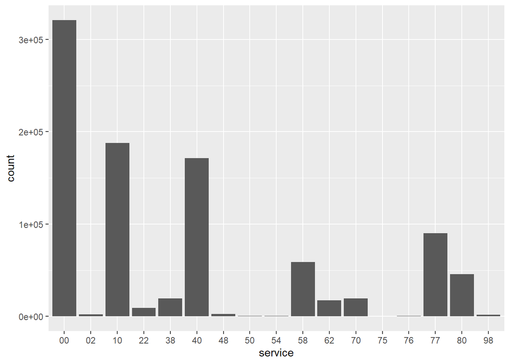

```r
ggplot(y,aes(service))+
  geom_bar(position='dodge')
```

PLOT 4

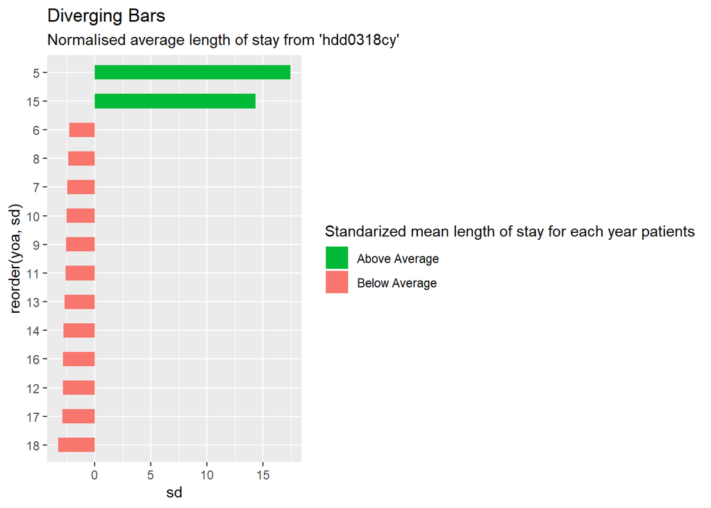

```r
y2=y %>%
  group_by(yoa) %>%
  summarise(mean_los=mean(los)) %>%
  mutate(centered_mean=mean(mean_los)) %>%
  mutate(sd=mean_los-centered_mean) %>%
  mutate(sd_level=ifelse(sd>0,"above","below"))

ggplot(y2, aes(x=reorder(yoa,sd), y=sd)) +
  geom_bar(stat='identity', aes(fill=sd_level), width=0.5) +
  scale_fill_manual(name="Standarized mean length of stay for each year patients",
  labels = c("Above Average", "Below Average"),
  values = c("above"="#00ba38", "below"="#f8766d")) +
  labs(subtitle="Normalised average length of stay from 'hdd0318cy'",
  title= "Diverging Bars") +
  coord_flip()
```

PLOT 5

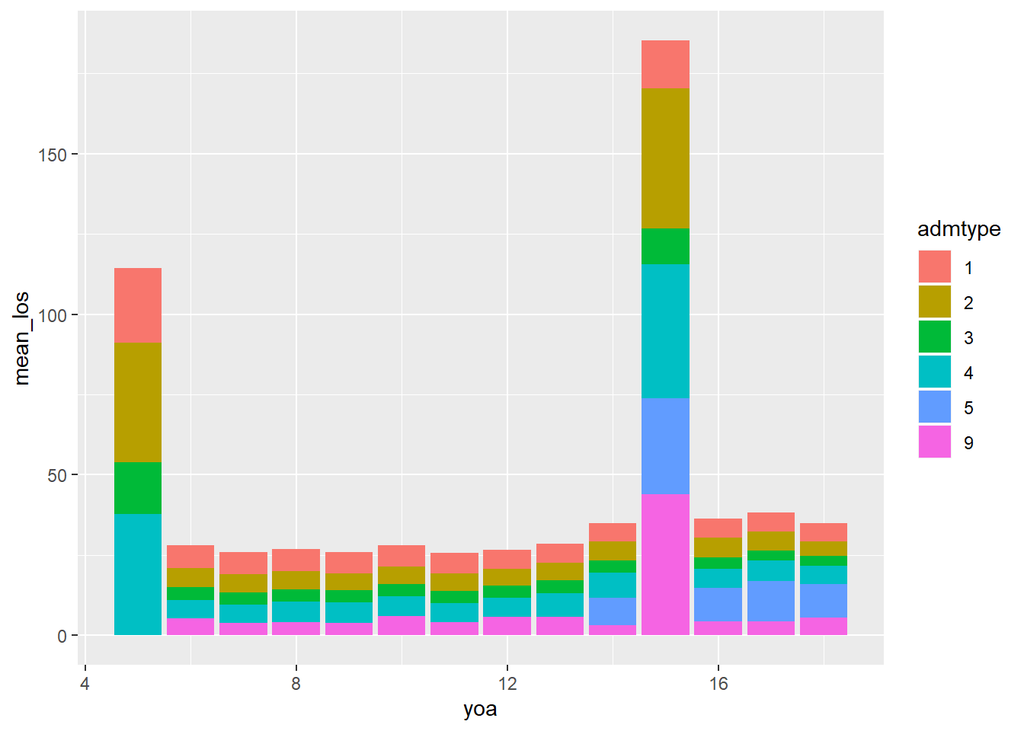

```r
y3=y %>%
  group_by(yoa,admtype) %>%
  summarise(mean_los=mean(los))
ggplot(y3,aes(yoa,mean_los,fill=admtype))+
geom_col()
```

PLOT 6

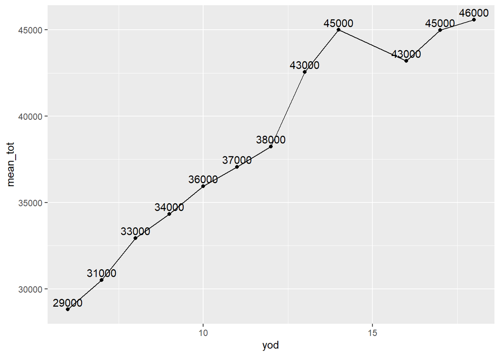

```r
a = y %>%
  group_by(yod) %>%
  summarise(mean_tot=mean(tot))
ggplot(a,aes(yod,mean_tot))+
  geom_line()+
  geom_text(aes(label=round(mean_tot,-3)),vjust = -0.4)+
  geom_point()
```

PLOT 7

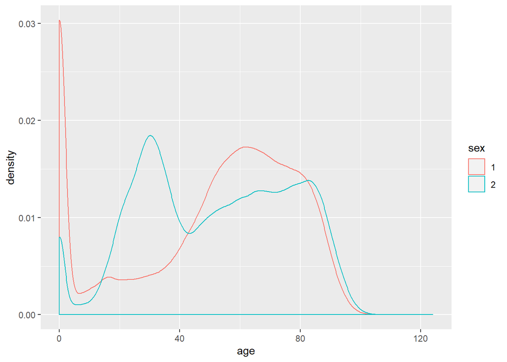

```r
ggplot(y,aes(age,color=sex))+
geom_density()
```

There are more male new born babies than female babies. PLOT 8

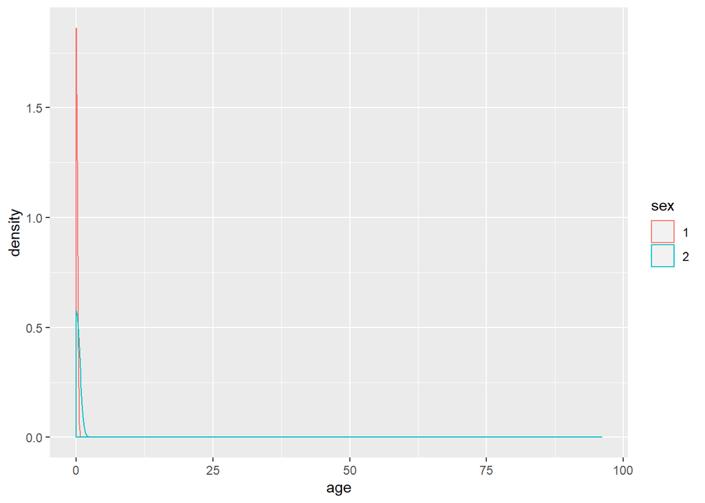

```r
B=y %>%
  filter(admtype==4)
ggplot(B,aes(age,color=sex))+
geom_density()
```

4=Newborn

PLOT 9

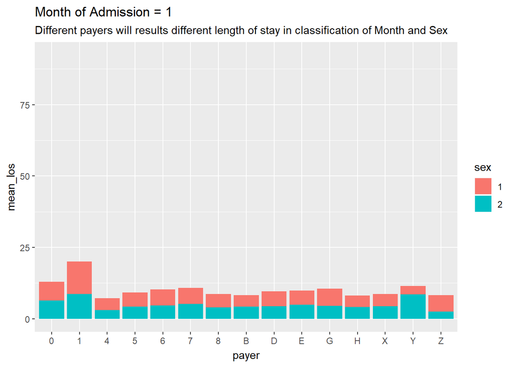

```r
C=y %>%
  group_by(moa,payer,sex) %>%
  summarise(mean_los=mean(los))


ggplot(C,aes(payer,mean_los,fill=sex))+
  geom_col()+
  transition_states(moa)+
  labs(subtitle="Different payers will results different length of stay in classification of Month and Sex", title= labs(title = 'Month of Admission = {closest_state}'))
```

Y is insurance payer missing, so we ignore it first. Due to unknown reasons that people who probably pay it by themselves stay longer in the hospital. Most of them are females. 2=female 1 = Medicaid insurance company provides insurant longer stay time in hospital. So, Question? Is Medicaid actually providing low-cost insurance coverage to people?

PLOT 10

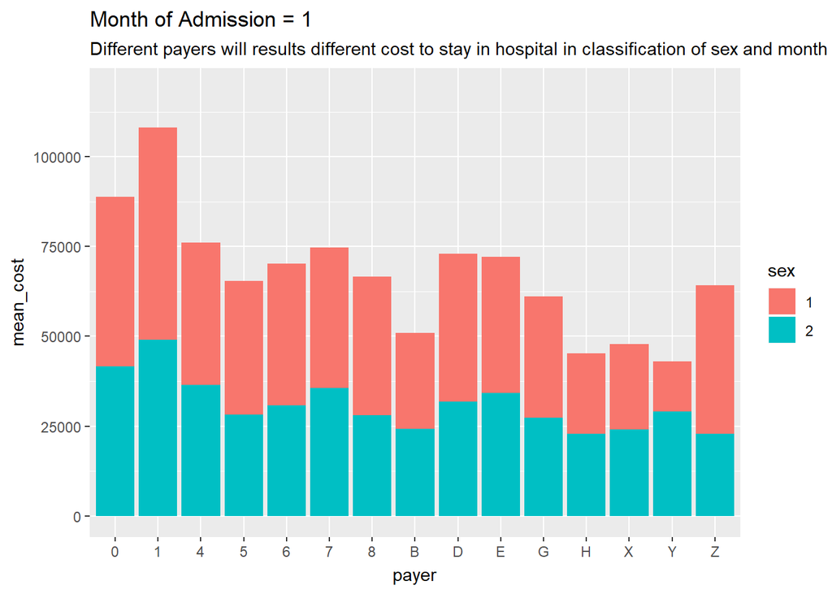

```r
D = y %>%
  group_by(payer,sex,moa) %>%
  summarise(mean_cost=mean(tot))
ggplot(D,aes(payer,mean_cost,fill=sex)) +
  geom_col()+
  transition_states(moa)+
  labs(subtitle="Different payers will results different cost to stay in hospital in classification of sex and month", title= labs(title = 'Month of Admission = {closest_state}'))
```

You can see Medicaid company pays the most comparing to other companies. Conclucion: Medicaid company is a very competitive insurance company which provides long time service of coverage, also cover a lot of payment.

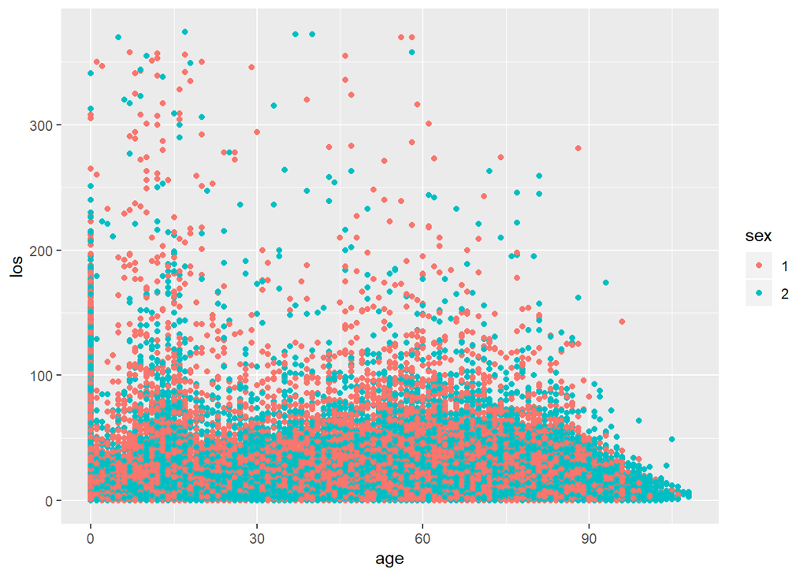

```r
#I have to remove outliers. I am removing los>375 and age>110

cleaned_y=y %>%
  filter(los<375) %>%
  filter(age<110)
ggplot(cleaned_y,aes(age,los,color=sex))+
  geom_point()
```

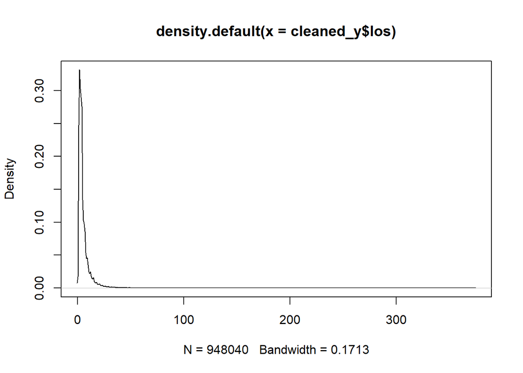

```r
plot(density(cleaned_y$los))
```